# Gender-Monitoring (Teil 3): Welchen Einfluss haben Störfaktoren?

09.10.2022

**Unterschiede zwischen den Erfolgsquoten von Frauen und Männern in der SNF-Förderung lassen sich durch vielfältige direkte und indirekte Einflüsse erklären. Ein Blick auf Störfaktoren, die das Ergebnis von Analysen verzerren können.**

Als Institution, die sich für Chancengleichheit einsetzt, will der SNF Forschende mit unterschiedlichem Hintergrund unterstützen. Deshalb untersucht er mit regelmässigen Analysen den Einfluss, den das Geschlecht auf die Bewilligung und Finanzierung von Gesuchen im Rahmen seiner Projektförderung hat. Die Erfolgs- und Finanzierungsquoten und deren Zusammenhang mit dem Geschlecht wurden unter anderem mit Regressionsmodellen analysiert. Für eine treffende Interpretation dieser Analysen ist es wichtig, im Modell relevante Störfaktoren zu berücksichtigen. Denn die Schlussfolgerungen können markant anders ausfallen, wenn die Störfaktoren nicht korrekt modelliert werden.

### Art der Institution, Erstgesuch und Alter der Gesuchstellenden

Die [erste Datengeschichte im Rahmen des SNF-Gender-Monitorings](https://data.snf.ch/stories/frauen-unterrepraesentiert-oder-unterfinanziert-de.html) präsentierte Zahlen zu den Erfolgsquoten von männlichen und weiblichen Gesuchstellenden. Diese unbereinigten Erfolgsquoten eignen sich jedoch nicht optimal zur Quantifizierung des Zusammenhangs zwischen Geschlecht und Fördererfolg. Zum Teil ist dies darauf zurückzuführen, dass für die Erfolgsquoten keine Störfaktoren berücksichtigt wurden. Möglich ist dies mit Regressionsmodellen, die wir entsprechend in dieser Analyse verwenden.

**Was ist ein Störfaktor?**

Ein Störfaktor oder eine Störvariable ist ein Element, das einen Einfluss auf die Zielgrösse hat, die wir analysieren wollen (d.h. im vorliegenden Fall der Finanzierungsentscheid), aber auch auf die Variable, deren Einfluss wir zu interpretieren versuchen (d.h. das Geschlecht). Weshalb es wichtig ist, Störfaktoren zu berücksichtigen, lässt sich am Beispiel des Zusammenhangs zwischen Alkoholkonsum und Krebs zeigen. Es ist bekannt, dass Rauchen das Risiko für Lungenkrebs erhöht und dass Rauchen und Alkoholkonsum häufig stark korrelieren. Eine statistische Modellierung der Häufigkeit von Lungenkrebs unter Verwendung des Alkoholkonsums als einziger «erklärender Variable» würde ein hochsignifikantes Ergebnis liefern und somit fälschlicherweise darauf hindeuten, dass Alkoholkonsum Lungenkrebs «verursacht». Wenn jedoch zusätzlich der Störfaktor Rauchen/Nichtrauchen ins Modell einbezogen wird, verringern sich die statistische Signifikanz und der Einfluss von Alkohol auf Lungenkrebs massiv oder verschwinden sogar vollständig. Mit der Analyse von Störfaktoren lassen sich die richtigen und sinnvollen Zusammenhänge ermitteln und schätzen. Mit anderen Worten: Störfaktoren wirken sich sowohl auf den untersuchten Einflussfaktor als auch auf die Zielgrösse aus und können die Resultate des Modells stark verändern. Aus diesem Grund sollten Ergebnisse stets um Störfaktoren «bereinigt» sein, indem diese ins statistische Modell integriert werden.

Wir betrachten mehrere potenzielle Störfaktoren, d. h. Variablen, die sowohl mit dem Geschlecht als auch mit der Erfolgsquote von Gesuchen in der Projektförderung korrelieren. Ein Beispiel ist die Art der Institutionen, bei denen die Gesuchstellenden tätig sind. Die erste Abbildung unten zeigt den Anteil von Männern und Frauen bei den verantwortlichen Gesuchstellenden nach Art der Forschungsinstitution. Hier ist festzustellen, dass Forscherinnen häufiger von Fachhochschulen und Pädagogischen Hochschulen kommen als Forscher, die dafür häufiger bei Institutionen des ETH-Bereichs arbeiten. Gemäss früheren Analysen haben Gesuche von ETH-Institutionen eine höhere Chance, vom SNF gefördert zu werden. Die Art der Institution korreliert also sowohl mit der Erfolgsquote als auch mit dem Geschlecht der Gesuchstellenden.

Ausserdem ist aus früheren Analysen bekannt, dass Erstgesuche von Forschenden eine geringere Erfolgsquote haben als solche von Forschenden, die schon einmal ein Gesuch einreichten. Interne Analysen ergaben auch, dass die Erfolgsquote junger Gesuchstellender tendenziell tiefer ist. Die zweite Abbildung unten zeigt deutlich, dass der Anteil von Erstgesuchen bei den Frauen höher ist. Die Nichtberücksichtigung dieses Störfaktors kann daher die Ergebnisse eines statistischen Modells stark verzerren und die Auswirkungen des Geschlechts auf die Erfolgsquoten künstlich aufblähen oder verschleiern.

Anteil der weiblichen und männlichen Gesuchstellenden nach Art der Institution im Zeitverlauf

[interactive chart not shown]

Anteil der weiblichen und männlichen verantwortlichen Gesuchstellenden nach Art der Institution von Oktober 2013 bis April 2022 in der Projektförderung des SNF (FH/PH: Fachhochschulen und Pädagogische Hochschulen).

Anteil der weiblichen und männlichen Erstgesuchstellenden nach Forschungsbereichen im Zeitverlauf

[interactive chart not shown]

Anteil der weiblichen und männlichen verantwortlichen Erstgesuchstellenden nach Forschungsbereich von Oktober 2013 bis April 2022 in der Projektförderung des SNF (GSW: Geistes- und Sozialwissenschaften, MINT: Mathematik, Informatik, Naturwissenschaften, Technik, LW: Lebenswissenschaften).

Anteil der weiblichen und männlichen Gesuchstellenden nach Art der Institution im Zeitverlauf

[interactive chart not shown]

Anteil der weiblichen und männlichen verantwortlichen Gesuchstellenden nach Art der Institution von Oktober 2013 bis April 2022 in der Projektförderung des SNF (FH/PH: Fachhochschulen und Pädagogische Hochschulen).

Anteil der weiblichen und männlichen Erstgesuchstellenden nach Forschungsbereichen im Zeitverlauf

[interactive chart not shown]

Anteil der weiblichen und männlichen verantwortlichen Erstgesuchstellenden nach Forschungsbereich von Oktober 2013 bis April 2022 in der Projektförderung des SNF (GSW: Geistes- und Sozialwissenschaften, MINT: Mathematik, Informatik, Naturwissenschaften, Technik, LW: Lebenswissenschaften).

### Unbereinigte und bereinigte Resultate

Zur Analyse der Erfolgsquoten nach Geschlecht modellieren wir daher die Förderentscheide auf der Ebene des einzelnen Gesuchs. Wir verwenden dazu logistische Regressionsmodelle für die binäre Zielvariable (bewilligt versus nicht bewilligt). Ein Regressionsmodell ist eine statistische Schätzung der Beziehung zwischen einer Zielvariablen und einer oder mehreren erklärenden Variablen. Bei der logistischen Regression ist die Zielvariable binär. Daraus resultiert keine direkte Schätzung für die Erfolgsquote, sondern ein Wert, der die Chance auf ein erfolgreiches Gesuch widerspiegelt. Die Wirkung der Faktoren, die die Erfolgschancen beeinflussen, wird dann mit dem Chancenverhältnis gemessen.

**Chancen, Chancenverhältnisse und Konfidenzintervalle**

Eine Chance (englisch Odd) ist definiert als Wahrscheinlichkeit eines bestimmten Ereignisses, geteilt durch die Wahrscheinlichkeit, dass ein beliebiges Ereignis ausser dieses bestimmte Ereignis eintritt. Die Chance, mit einem Würfel eine Sechs zu würfeln, ist zum Beispiel 1/6 geteilt durch 5/6, also 1/5 (0,2). Das Chancenverhältnis (englisch Odds-Ratio) ist der Quotient zweier Chancen. Ein Beispiel: die Chance, eine Sechs zu würfeln, während man einen Glücksbringer trägt, geteilt durch die Chance, eine Sechs zu würfeln, ohne einen Glücksbringer zu tragen. Chancenverhältnisse können jeden Wert zwischen 0 und unendlich haben. Ein Chancenverhältnis von 1 bedeutet, dass beide Chancen gleich sind, d. h. dass der «untersuchte Faktor» keinen Einfluss auf die Eintretenswahrscheinlichkeit hat. Statistische Schätzungen wie das Chancenverhältnis werden zusammen mit einem Konfidenzintervall (KI) angegeben. Mit diesem Intervall wird quantifiziert, wie unsicher eine Schätzung ist. So ist das 95%-Konfidenzintervall der Bereich, in dem die Schätzung bei einer Wiederholung des Experiments in 95% der Fälle zu erwarten ist. Wenn ein Konfidenzintervall für ein Chancenverhältnis den Wert 1 enthält, gilt der geschätzte Effekt als statistisch nicht signifikant, während das Ergebnis als statistisch signifikant gilt, wenn das Intervall 1 nicht enthält.

In unserem Fall interessiert uns, ob die Erfolgschancen für weibliche und männliche Gesuchstellende unterschiedlich sind. Die in der nachstehenden Tabelle aufgeführten Chancenverhältnisse wurden anhand der beiden zuletzt ausgewerteten Ausschreibungen und für jeden Forschungsbereich getrennt berechnet. Bei den unbereinigten Versionen wurden Störfaktoren (Alter, Erstgesuch und Institutionsart) nicht berücksichtigt, bei den bereinigten wurden sie hingegen berücksichtigt. Beispielsweise beträgt das unbereinigte Chancenverhältnis für das Geschlecht (weiblich versus männlich) in den GSW 1,15, d. h. für Frauen ist die Chance, dass ihr Gesuch bewilligt wird, 1,15 Mal so hoch wie für männliche Gesuchstellende. Da das entsprechende 95%-Konfidenzintervall 1 enthält, ist dieser Geschlechter-Effekt jedoch statistisch nicht signifikant. In den beiden anderen Forschungsbereichen sind die Chancen auf Förderbeiträge für weibliche bzw. männliche Gesuchstellende in den nicht-bereinigten Modellen etwa gleich. Die bereinigten Chancenverhältnisse sind jedoch grösser als die unbereinigten, was darauf hindeutet, dass Gesuchstellerinnen nach der Bereinigung um Störfaktoren eine höhere Erfolgsquote haben als Gesuchsteller. Die beobachteten Effekte liegen allerdings alle in der Nähe von 1 (dem Wert des Chancenverhältnisses bei Chancengleichheit der Geschlechter) und sind statistisch nicht signifikant.

Bereinigte und unbereinigte Gender-Odds-Ratio der weiblichen bzw. männlichen Gesuchstellenden (Konfidenzintervall: 95%) aus den logistischen Regressionsmodellen für die letzten beiden evaluierten Ausschreibungen der Projektförderung (Oktober 2021 und April 2022) nach Forschungsbereich

| Forschungsbereich | Unbereinigte OR (95% KI) | Bereinigte OR (95% KI) |
| --- | --- | --- |
| GSW | 1.15 (0.80 to 1.65) | 1.23 (0.84 to 1.79) |
| MINT | 1.00 (0.65 to 1.51) | 1.18 (0.76 to 1.81) |
| LW | 1.00 (0.72 to 1.40) | 1.10 (0.78 to 1.55) |

Unbereinigte geschlechtsspezifische Chancenverhältnisse von weiblichen und männlichen Gesuchstellenden im Zeitverlauf

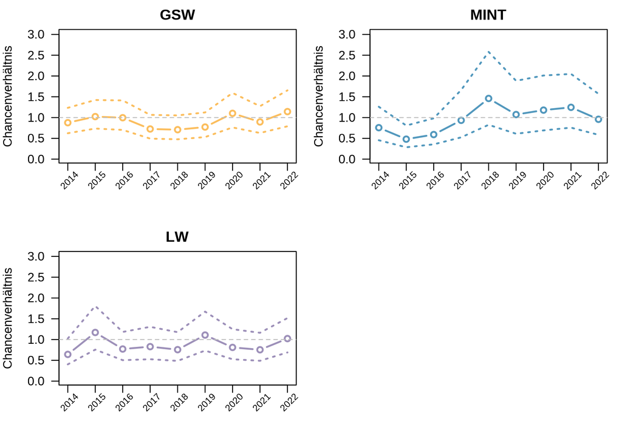

Unbereinigte Gender-Chancenverhältnisse von weiblichen und männlichen Gesuchstellenden (KI 95 %) aus den gemischten logistischen Regressionsmodellen nach Forschungsbereich für die Entscheidjahre 2014-2022 in der Projektförderung des SNF. (Da etwa 50-65% der Gesuchstellenden pro Forschungsbereich in diesem Zeitraum mehrere Gesuche einreichten, enthält das Modell zur Berücksichtigung dieser Datenstruktur einen zufälligen Achsenabschnitt für die gesuchstellende Person.)

Bereinigte Gender-Chancenverhältnisse für weibliche und männliche Gesuchstellende im Zeitverlauf

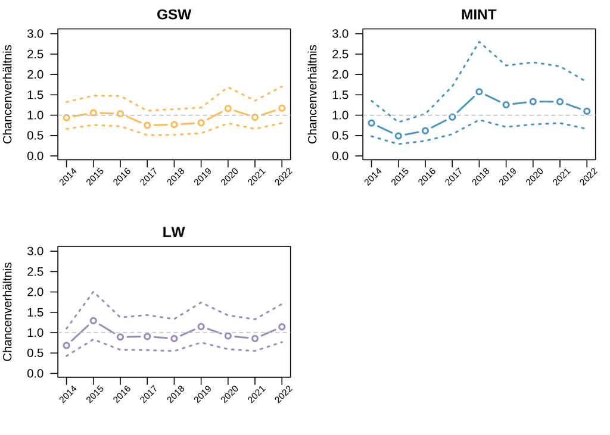

Bereinigte Gender-Chancenverhältnisse für weibliche und männliche Gesuchstellende (KI: 95%) aus den gemischten logistischen Regressionsmodellen nach Forschungsbereich für die Entscheidjahre 2014-2022 in der Projektförderung des SNF. (Da etwa 50-65% der Gesuchstellenden pro Forschungsbereich in diesem Zeitraum mehrere Gesuche einreichten, enthält das Modell zur Berücksichtigung dieser Datenstruktur einen zufälligen Achsenabschnitt für die gesuchstellende Person.)

Unbereinigte geschlechtsspezifische Chancenverhältnisse von weiblichen und männlichen Gesuchstellenden im Zeitverlauf

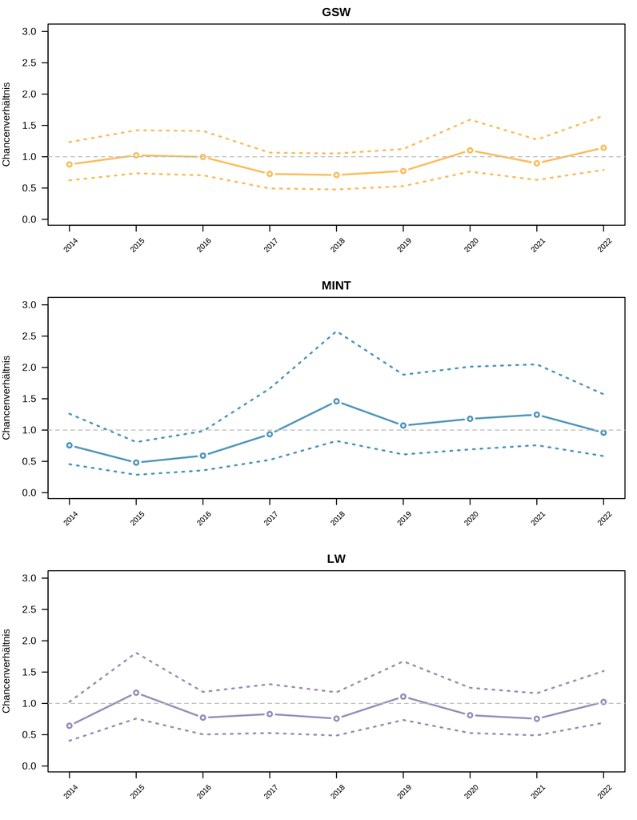

Unbereinigte Gender-Chancenverhältnisse von weiblichen und männlichen Gesuchstellenden (KI 95 %) aus den gemischten logistischen Regressionsmodellen nach Forschungsbereich für die Entscheidjahre 2014-2022 in der Projektförderung des SNF. (Da etwa 50-65% der Gesuchstellenden pro Forschungsbereich in diesem Zeitraum mehrere Gesuche einreichten, enthält das Modell zur Berücksichtigung dieser Datenstruktur einen zufälligen Achsenabschnitt für die gesuchstellende Person.)

Bereinigte Gender-Chancenverhältnisse für weibliche und männliche Gesuchstellende im Zeitverlauf

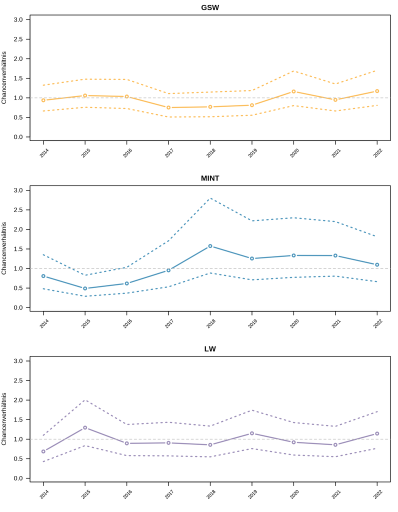

Bereinigte Gender-Chancenverhältnisse für weibliche und männliche Gesuchstellende (KI: 95%) aus den gemischten logistischen Regressionsmodellen nach Forschungsbereich für die Entscheidjahre 2014-2022 in der Projektförderung des SNF. (Da etwa 50-65% der Gesuchstellenden pro Forschungsbereich in diesem Zeitraum mehrere Gesuche einreichten, enthält das Modell zur Berücksichtigung dieser Datenstruktur einen zufälligen Achsenabschnitt für die gesuchstellende Person.)

### SNF-Monitoring wird weitergeführt

Bei den beiden jüngsten ausgewerteten Ausschreibungen gibt es keine statistische Evidenz für eine geschlechtsspezifische Verzerrung des Fördererfolgs in der Projektförderung, weder mit noch ohne Berücksichtigung der Störfaktoren. Dennoch gab es bei gewissen früheren Ausschreibungen Hinweise auf eine solche Verzerrung zugunsten der Männer. Dies unterstreicht die Notwendigkeit eines sorgfältigen Gender-Monitorings, das die Eigenheiten der einzelnen Förderprogramme beachtet und alle relevanten Störfaktoren systematisch identifiziert und berücksichtigt. Im Rahmen des regelmässigen Gender-Monitorings untersucht der SNF neben den Förderbeiträgen, die weibliche und männliche Gesuchstellende erhalten, auch die Bewertungen der externen Gutachten und der internen Evaluationsgremien sowohl deskriptiv als auch mit Statistikmodellen. Diese Ergebnisse werden in einer späteren Datengeschichte der Serie «Gender-Monitoring» präsentiert.

### Serie zum Gender Monitoring des SNF

Der SNF analysiert systematisch die Anteile der Frauen und Männer in seinen Förderinstrumenten. Mit Hilfe dieses Gender Monitorings wollen wir unsere Auswahlverfahren und unser Angebot so weiterentwickeln, dass Frauen möglichst gleiche Chancen haben. In einer Serie stellen wir ausgewählte Daten vor und beleuchten unterschiedliche Aspekte.

[Teil 1: So schneiden Frauen in der Projektförderung ab](https://data.snf.ch/stories/frauen-unterrepraesentiert-oder-unterfinanziert-de.html)

[Teil 2: Je höher die Karrierestufe, desto weniger Frauen](https://data.snf.ch/stories/je-hoeher-die-karrierestufe-desto-weniger-frauen-de.html)

[Teil 3 (aktuell): Welchen Einfluss haben Störfaktoren?](https://data.snf.ch/stories/der-einfluss-von-stoerfaktoren-de.html)

Daten, Text und Code dieser Datengeschichte sind [auf Github verfügbar](https://github.com/snsf-data/datastory_gender_monitoring_confounders) und [auf Zenodo archiviert](https://doi.org/10.46446/datastory.gender-monitoring-confounders). DOI: 10.46446/datastory.gender-monitoring-confounders